# notebook15dc3223e4

[figure not shown]

M2.975 · Deep Learning · PAC2

2024-2 · Màster universitari en Ciència de dades (Data science)

Estudis d'Informàtica, Multimèdia i Telecomunicació

# PAC 2: Xarxes neuronals recurrents amb Keras

Consideracions generals:

- Aquesta PAC s'ha de realitzar de forma **estrictament individual**. Qualsevol indicatiu de còpia serà penalitzat amb un suspens (D) per a totes les parts implicades i la possible avaluació negativa de l'assignatura de manera íntegra.
- És necessari que l'estudiant indiqui **totes les fonts** que ha utilitzat per a la realització de la PAC. De no ser així, es considerarà que l'estudiant ha comès plagi, sent penalitzat amb un suspens (D) i la possible avaluació negativa de l'assignatura de manera íntegra.

Format de l'entrega:

- Alguns exercicis poden suposar diversos minuts d'execució, per la qual cosa l'entrega s'ha de fer en **format notebook** i en **format html**, on es vegi el codi, els resultats i comentaris de cada exercici. Es pot exportar el notebook a HTML des del menú File $\to$ Download as $\to$ HTML.
- Existeix un tipus de cel·la especial per allotjar text. Aquest tipus de cel·la us serà molt útil per respondre a les diferents preguntes teòriques plantejades al llarg de l'activitat. Per canviar el tipus de cel·la a aquest tipus, en el menú: Cell $\to$ Cell Type $\to$ Markdown.

# 0. Context i càrrega de llibreries

# Xarxes Neuronals Recurrents

Les **xarxes neuronals recurrents (RNNs)** es basen justament en aquesta idea: són xarxes dissenyades per processar seqüències, mantenint un estat ocult que evoluciona amb el temps i resumeix la informació rellevant del passat. Així, les RNN permeten capturar patrons temporals i contextuals molt més llargs que els models clàssics de $n$-grames, sent una eina fonamental per a tasques com a generació de text, anàlisi de sentiments, traducció automàtica, entre d'altres.

**En aquesta pràctica, a la primera part explorarem com funcionen les RNNs des de zero, implementant i entrenant una xarxa bàsica per a tasques de modelatge de llenguatge. A la segona, farem servir models ja implementats per aplicar-lo a un problema real d'estimació del consum d'energia.**

```python
# LLIBRERIES NECESSÀRIES
import tensorflow as tf
import numpy as np
```

```python
# !pip install "tensorflow<2.11"
```

# 1. Implementar una RNN des de Zero (Pas a Pas)

**1.1. Implementació RNN (Forward Pass) des de Zero**

**Què és una RNN?** Una Xarxa Neuronal Recurrent (RNN) és una arquitectura dissenyada per processar dades seqüencials (com text o sèries de temps). La seva característica clau és l'**estat ocult** (`h_t`), que actua com a memòria dinàmica emmagatzemant informació contextual de tots els passos anteriors. A diferència dels models de n-grames, les RNNs poden capturar dependències a *llarg termini* mitjançant aquesta memòria recurrent, processant seqüències de longitud variable de manera eficient.

**Formulació Matemàtica** A cada pas de temps `t`, la RNN realitza dues accions fonamentals:

1. **Actualització de l'estat ocult**: Combina l'entrada actual `x_t` i l'estat ocult anterior `h_{t-1}` mitjançant una transformació lineal seguida d'una no-linealitat (usualment `tanh`):

   $$ h_t = \tanh(\underbrace{W_{xh} x_t}_{\text{Contribució actual}} + \underbrace{W_{hh} h_{t-1}}_{\text{Memòria passada}} + b_h) $$
   - **$W_{xh}$**: Matriu de pesos que projecta l'entrada a l'espai ocult (dimensió: `d × H`).
   - **$W_{hh}$**: Matriu de pesos recurrents que actualitza la memòria (dimensió: `H × H`).
   - **$b_h$**: Vector de biaix (dimensió: `H`).
   - **`tanh`**: Funció d'activació que acota valors entre [-1, 1], estabilitzant gradients.
2. **Generació de sortida (es veu a l'exercici 1.2.)**: Per a modelatge del llenguatge, se sol afegir una capa lineal addicional que mapeja $h_t$ a logits per predir el proper token: $$ o_t = W_{ho} h_t + b_o $$ On $W_{ho}$ (dimensió: `H × |Vocabulari|`) i $b_o$ són paràmetres de sortida.

**Flux d'informació** A cada pas $t$, la RNN processa seqüencialment:

- Pren l'entrada actual $x_t$ (ex: embedding d'un caràcter).
- Combina $x_t$ amb l'estat anterior $h_{t-1}$ per calcular $h_t$.
- Usa $h_t$ per predir el següent element a la seqüència.

Aquesta recurrència permet que la informació flueixi a través del temps, donant a la RNN la seva capacitat de *recordar* patrons temporals.

**Exercici [0.75 pts.]:** Defineix un model de xarxa neuronal recurrent (RNN) seguint els passos per construir l'arquitectura del model descrita a continuació:

**Instruccions per Implementar la RNN (Pas a Pas):**

**1. Crea una classe `RNNScratch`:**

- Per això, hereta de `tf.Module` per aprofitar les utilitats de TensorFlow-
- Defineix els següents atributs al constructor:
  - `num_inputs`: Dimensió dels vectors d'entrada (ex: mida del vocabulari o embeddings).
  - `num_hiddens`: Dimensió de l'estat ocult (`H`).
  - `sigma`: Desviació estàndard per a inicialització de pesos.

**2. Dins del constructor, defineix `W_xh`, `W_hh` i `b_h` com a variables entrenables de TensorFlow.**

- **`W_xh`**: Pesos per projectar l'entrada `x_t` a l'espai ocult.
  - Forma: `(num_inputs, num_hiddens)`.
  - Inicialitzat amb valors aleatoris de distribució normal escalats per `sigma`.
- **`W_hh`**: Pesos recurrents per propagar l'estat ocult.
  - Forma: `(num_hiddens, num_hiddens)`.
  - Inicialitzat igual que `W_xh`.
- **`b_h`**: Biaix de l'estat ocult.
  - Inicialitzat amb zeros (forma `(num_hiddens,)`).

**3. Implementar el mètode `forward`:**

- Aquesta funció rebrà dos paràmetres:
  - `inputs`: Tensor de forma `(T, batch_size, num_inputs)`, on `T` és la longitud de la seqüència.
  - `state`: Estat ocult inicial (si és `None`, s'inicialitza amb zeros).
- La lògica dins aquesta funció és la següent:
  - Verifiquem si `state` no es proporciona (és None), inicialitzar-lo com a tensor de zeros amb forma `(batch_size, num_hiddens)`.
  - A continuació, cal iterar sobre cada pas de temps `T` (ex: bucle for):
    - Per a cada X que rebem que té la forma `(batch_size, num_inputs)` a :
      - Calculeu `tf.matmul(X, self.W_xh)`: Projecció de l'entrada actual.
      - Calcular `tf.matmul(state, self.W_hh)`: contribució de l'estat anterior.
      - Sumar ambdós termes i el biaix `self.b_h`.
      - Aplicar `tanh` per obtenir el nou estat: `state = tf.tanh(...)`.
    - Emmagatzemar l'estat en una llista d'outputs (que ha de ser inicialitzada prèviament).

**Pistes:**

- **Batch Processing**: Cada `X` al bucle té forma `(batch_size, num_inputs)`, permetent processar múltiples seqüències en paral·lel.
- **Recurrència**: L'estat `state` s'actualitza a cada pas i es passa al següent, mantenint la memòria temporal.
- **Sortida**: `outputs` és una llista amb els estats ocults a cada pas, útil per connectar a capes posteriors (ex: predicció de tokens).

```python
# Completa l'exercici

class RNNScratch(tf.Module):
    def __init__(self, num_inputs, num_hiddens, sigma=0.01):
        # Completa lògica del constructor
        self.num_inputs = num_inputs
        self.num_hiddens = num_hiddens
        self.sigma = sigma
        self.W_xh = tf.Variable(tf.random.normal([num_inputs, num_hiddens], stddev=sigma), name='W_xh')
        self.W_hh = tf.Variable(tf.random.normal([num_hiddens, num_hiddens], stddev=sigma), name='W_hh')
        self.b_h = tf.Variable(tf.zeros([num_hiddens]), name='b_h')

    def forward(self, inputs, state=None):
        # Completa lògica de la funció
        num_steps, batch_size, num_inputs = tf.shape(inputs)[0], tf.shape(inputs)[1], tf.shape(inputs)[2]
        if(state == None):
            state = tf.zeros([batch_size,num_hiddens])
        outputs = []
        for i in range(num_steps):
            X = inputs[i]
            state = tf.tanh(tf.matmul(X, self.W_xh) + tf.matmul(state, self.W_hh) + self.b_h)
            outputs.append(state)
        return outputs, state
```

**Exercici [0.25]:** Verifica el seu funcionament amb la cel·la següent i respon a la pregunta següent en una sola línia. De què està compost la variable 'outputs'?

```python
batch_size, num_inputs, num_hiddens, num_steps = 2, 16, 32, 100
rnn = RNNScratch(num_inputs, num_hiddens)
X = tf.ones((num_steps, batch_size, num_inputs))
outputs, state = rnn.forward(X)  # Use forward() instead of calling rnn directly
```

## 1.2. RNN per a Model del Llenguatge

Ara que ja tens implementada la classe `RNNScratch`, el següent pas és fer-la servir com a base per construir un **model de llenguatge**. Aquest tipus de models són la base de sistemes d'autocompletat de text, predicció de paraules o generació de text.

### Què canvia ara?

Quan treballem amb models de llenguatge, **les entrades i les sortides pertanyen al mateix vocabulari**. Per exemple, si esteu entrenant un model per predir la propera paraula en una frase, tant la paraula actual (entrada) com la següent (sortida esperada) són paraules del vocabulari. Això vol dir que:

- Cada paraula es codifica com un vector (per exemple, one-hot).
- La dimensió d'aquests vectors és igual a la mida del vocabulari.
- La sortida del model ha de ser una predicció sobre quin és el proper token, també expressat en termes del vocabulari.

### Què es proporciona?

- La classe `RNNLMScratch`.
- **`__init__`**: rep la RNN prèviament definida, la mida del vocabulari (ja que tant l'entrada com la sortida són en aquest espai) i una taxa d'aprenentatge.
- **`init_params`**: defineix els pesos i biaixos de la capa de sortida. Aquesta capa pren l'estat ocult a cada pas i genera una distribució sobre el vocabulari (probabilitat que cada paraula sigui la següent).

```python
class RNNLMScratch(tf.Module):
    """ RNN-based language model """
    def __init__(self, rnn, vocab_size, lr=0.01):
        super().__init__()

        self.init_params()

    def init_params(self):
        self.W_hq = tf.Variable(tf.random.normal(
            (self.rnn.num_hiddens, self.vocab_size)) * self.rnn.sigma)
        self.b_q = tf.Variable(tf.zeros(self.vocab_size))
```

## 1.2.1. Codificació One-Hot

Què és la codificació one-hot? Cada token (caràcter) es representa com un vector de longitud igual a la mida del vocabulari, amb un 1 a l'índex corresponent al token i 0 a les altres posicions.

Per exemple, si `vocab = {'a':0, 'b':1, 'c':2}`, aleshores:

- `one_hot(0)` → `[1, 0, 0]`
- `one_hot(2)` → `[0, 0, 1]`

```python
class RNNLMScratch(tf.Module):
    """ RNN-based language model """
    def __init__(self, rnn, vocab_size, lr=0.01):
        super().__init__()

        self.init_params()

    def init_params(self):
        self.W_hq = tf.Variable(tf.random.normal(
            (self.rnn.num_hiddens, self.vocab_size)) * self.rnn.sigma)
        self.b_q = tf.Variable(tf.zeros(self.vocab_size))

    # Afegim la funció one-hot
    def one_hot(self, X):
        return tf.one_hot(tf.transpose(X), self.vocab_size)
```

**Exercici [0.5 pts.]:** Podries dir què és el que fa la funció anterior one_hot sobre la matriu X donada una mida de vocabulari?

Completa l'exercici amb una explicació breu

La funcio One-Hot, suposant que X es una matriu on tenim totes les linees de text codificades en el nostre vocabulari, per exemple de la manera [[1,3],[1,2]] on aquest numeros son paraules del nostre diccionari, generarem una matriu amb la forma: tamany maxim de les cadenes x numero de cadenes x longitud del vocabulari i aquesta representacio tindra la seguent forma, suposant que la longitud del vocavulari es 3 [[[1,0,0],[0,0,1]],[[1,0,0],[0,1,0]]] on cada component representa una paraula sent un vector que es zero a tots els llocs excepte en el index de la paraula que representa al nostre vocabulari

## 1.2.2. Capa de sortida

Després d'obtenir cada estat ocult $h_t $, volem projectar-lo a l'espai del vocabulari:

$ o_t = h_t W_{hq} + b_q $

On:

- $h_t \in \mathbb{R}^{H} $
- $W_{hq} \in \mathbb{R}^{H \times V} $
- $b_q \in \mathbb{R}^{V} $

$o_t \in \mathbb{R}^{V} $: puntuacions sense normalitzar (logits) sobre el vocabulari.

Finalment, cal afegir una funció `output_layer` dins de la nostra classe `RNNLMScratch` que pren tots els estats ocults produïts per la RNN i, per a cadascú, aplica la transformació lineal (`W_hq`, `b_q`) que projecta aquest vector a l'espai del vocabulari. Després els apila per tornar un tensor de forma `(batch_size, T, vocab_size)`.

Implementa el mètode `output_layer(self, rnn_outputs)` dins de la classe `RNNLMScratch`, que ha de fer el següent:

1. Rep una llista de tensors `rnn_outputs`, que són els estats ocults generats per la RNN a cada pas de la seqüència. Cadascun d'aquests tensors té forma `(batch_size, num_hiddens)`.
2. Per a cada estat ocult `H`, aplica una capa lineal:

   $\text{output} = H \cdot W_{hq} + b_q$

   On:
   - `W_hq` és una matriu de pesos de forma `(num_hiddens, vocab_size)`
   - `b_q` és un vector de biaix de forma `(vocab_size,)`
3. Retorna un únic tensor de forma `(batch_size, T, vocab_size)`, on `T` és la longitud de la seqüència.

**Pista**: podeu utilitzar `tf.stack` per convertir la llista de prediccions per pas en un únic tensor.

**Exercici [0.25 pts.]:** Afegeix la capa final de la sortida a la classe amb què estem treballant:

```python
# Completa l'exercici
class RNNLMScratch(tf.Module):
    def __init__(self, rnn, vocab_size, lr=0.01):
        super().__init__()
        self.rnn = rnn
        self.vocab_size = vocab_size
        self.lr = lr
        self.init_params()

    def init_params(self):
        self.W_hq = tf.Variable(tf.random.normal(
            (self.rnn.num_hiddens, self.vocab_size)) * self.rnn.sigma)
        self.b_q = tf.Variable(tf.zeros(self.vocab_size))

    # Afegim la funció one-hot
    def one_hot(self, X):

        return tf.one_hot(tf.transpose(X), self.vocab_size)

    def output_layer(self, rnn_outputs):
        for i in range(len(rnn_outputs)):
            rnn_outputs[i] = tf.matmul(rnn_outputs[i], self.W_hq) + self.b_q
        output = tf.stack(rnn_outputs)
        return output
```

## Exercici 1.2.3: Entrenament del Model de Llenguatge

**Unirem totes les peces** per construir un **model de llenguatge entrenable des de zero**. Primer copia els següents mètodes per completar la classe `RNNLMScratch` amb els següents mètodes:

- `forward`: executa una passada completa pel model (one-hot → RNN → capa de sortida).
- `loss`: calcula la pèrdua cross-entropy entre la predicció i la seqüència esperada.
- `train_step`: realitza una actualització de paràmetres usant `GradientTape`.

```
def forward(self, X, state=None):
    X = self.one_hot(X)  # Convertim a one-hot: (T, batch_size, vocab_size)
    rnn_outputs, state = self.rnn.forward(X, state)
    logits = self.output_layer(rnn_outputs)  # (batch_size, T, vocab_size)
    return logits, state

def loss(self, logits, labels):
    loss = tf.nn.sparse_softmax_cross_entropy_with_logits(labels=labels, logits=logits)
    return tf.reduce_mean(loss)

def train_step(self, X, y, state=None):
    with tf.GradientTape() as tape:
        logits, state = self.forward(X, state)
        l = self.loss(logits, y)

    params = [self.W_hq, self.b_q, self.rnn.W_xh, self.rnn.W_hh, self.rnn.b_h]
    grads = tape.gradient(l, params)

    for p, g in zip(params, grads):
        p.assign_sub(self.lr * g)

    return l, state
```

Validarem que tot el teu model funciona correctament, **creant dades fictícies**. Farem servir nombres enters aleatoris com si fossin IDs de paraules d'un vocabulari.

```python
class RNNLMScratch(tf.Module):
    def __init__(self, rnn, vocab_size, lr=0.01):
        super().__init__()
        self.rnn = rnn
        self.vocab_size = vocab_size
        self.lr = lr
        self.init_params()

    def init_params(self):
        self.W_hq = tf.Variable(tf.random.normal(
            (self.rnn.num_hiddens, self.vocab_size)) * self.rnn.sigma)
        self.b_q = tf.Variable(tf.zeros(self.vocab_size))

    # Afegim la funció one-hot
    def one_hot(self, X):
        return tf.one_hot(tf.transpose(X), self.vocab_size)

    def output_layer(self, rnn_outputs):
        for i in range(len(rnn_outputs)):
            rnn_outputs[i] = tf.matmul(rnn_outputs[i], self.W_hq) + self.b_q
        output = tf.stack(rnn_outputs)
        return output
    def forward(self, X, state=None):
        X = self.one_hot(X)  # Convertim a one-hot: (T, batch_size, vocab_size)
        rnn_outputs, state = self.rnn.forward(X, state)
        logits = self.output_layer(rnn_outputs)  # (batch_size, T, vocab_size)
        return logits, state

    def loss(self, logits, labels):
        loss = tf.nn.sparse_softmax_cross_entropy_with_logits(labels=labels, logits=logits)
        return tf.reduce_mean(loss)

    def train_step(self, X, y, state=None):
        with tf.GradientTape() as tape:
            logits, state = self.forward(X, state)
            l = self.loss(logits, y)

        params = [self.W_hq, self.b_q, self.rnn.W_xh, self.rnn.W_hh, self.rnn.b_h]
        grads = tape.gradient(l, params)

        for p, g in zip(params, grads):
            p.assign_sub(self.lr * g)

        return l, state
```

**Exercici [0.25 pts.]:** Heu d'instanciar el model de RNN i el de RNNLMScratch. Posteriorment inicialitza de manera aleatòria els conjunt de dades X_train i y_train amb una mida de vocabulari `vocab_size`. Finalment, entrena el model amb el codi que t'hem proporcionat.

```python
tf.random.uniform(shape = (1, 3 , 100), maxval= 6, dtype=tf.dtypes.int32).shape
```

```
TensorShape([1, 3, 100])
```

```python
# Completa l'exercici

# Paràmetres per generar dades simulades
vocab_size = 10       # Nombre de paraules en el vocabulari
num_hiddens = 32      # Mida de l'estat ocult
num_steps = 5         # Longitud de les seqüències
batch_size = 2        # Nombre d'exemples en paral·lel

# Instanciem el model base i el model de llenguatge
rnn = RNNScratch(vocab_size, num_hiddens)
model = RNNLMScratch(rnn, vocab_size)

# Creem dades aleatòries que simulen seqüències de paraules
X_train = tf.random.uniform(shape = ( num_steps, batch_size), maxval=vocab_size, dtype=tf.dtypes.int32)
y_train = tf.random.uniform(shape = ( batch_size, num_steps ), maxval=vocab_size, dtype=tf.dtypes.int32)

# Entrenament simple durant 100 èpoques
num_epochs = 100
state = None
for epoch in range(num_epochs):
    loss, state = model.train_step(X_train, y_train, state)
    if (epoch + 1) % 10 == 0:
        print(f'Epoch {epoch+1}, Loss: {loss.numpy():.4f}')
```

```
Epoch 10, Loss: 2.2936
Epoch 20, Loss: 2.2838
Epoch 30, Loss: 2.2742
Epoch 40, Loss: 2.2647
Epoch 50, Loss: 2.2555
Epoch 60, Loss: 2.2464
Epoch 70, Loss: 2.2376
Epoch 80, Loss: 2.2289
Epoch 90, Loss: 2.2204
Epoch 100, Loss: 2.2120
```

# 2. Implementació d'una GRU des de Zero

Un cop comprès com funciona una RNN simple, és el moment d'anar un pas més enllà i construir una **GRU (Gated Recurrent Unit)**. Aquesta arquitectura introdueix mecanismes de control més sofisticats que milloren el flux d'informació i mitiguen el problema de l'esvaïment del gradient.

## 2.1. Crea una classe `GRUScratch`:

- Hereta de `tf.Module` per organitzar els paràmetres i facilitar el seguiment amb TensorFlow.
- Al constructor defineix els atributs següents:
  - `num_inputs`: Dimensió dels vectors dʻentrada.
  - `num_hiddens`: Dimensió de l'estat ocult (`H`).
  - `sigma`: escala per inicialitzar els pesos amb una distribució normal.

### **1. Defineix els pesos i biaixos necessaris per a les portes de la GRU:**

Una GRU utilitza tres components principals:

- **Porta de reinici (`r`)**: decideix quant de l'estat anterior s'ha d'oblidar.
- **Porta d'actualització (`z`)**: decideix quant del nou estat candidat s'hi incorpora.
- **Estat candidat (`h̃_t`)**: nova informació calculada que pot reemplaçar l'estat anterior.

Cada component té els seus propis pesos:

#### **Pesos per a les entrades `x_t`**:

- `W_xr`: per a la porta de reinici → forma `(num_inputs, num_hiddens)`
- `W_xz`: per a la porta d'actualització → forma `(num_inputs, num_hiddens)`
- `W_xh`: per a l'estat candidat → forma `(num_inputs, num_hiddens)`

#### **Pesos per als estats anteriors `h_{t-1}`**:

- `W_hr`: recurrent de la porta de reinici → forma `(num_hiddens, num_hiddens)`
- `W_hz`: recurrent de la porta d'actualització → forma `(num_hiddens, num_hiddens)`
- `W_hh`: recurrent de l'estat candidat → forma `(num_hiddens, num_hiddens)`

#### **biaixos (bias)**:

- `b_r`, `b_z`, `b_h`: un per cada component, de forma `(num_hiddens,)`

Tots aquests pesos han de ser inicialitzats:

- Els pesos amb una distribució normal escalada per `sigma`.
- Els biaixos amb zeros.

### **2. Implementa el mètode `forward`:**

- Aquest mètode rep:
  - `inputs`: Tensor de forma `(T, batch_size, num_inputs)` (seqüència temporal).
  - `state`: Estat ocult inicial. Si no es proporciona, s'inicialitza amb zeros.

#### **Lògica del pas temporal**:

Per a cada pas de temps `t`, amb entrada `X_t` i estat ocult `h_{t-1}`:

1. **Calcula la porta de reinici (`r`)**: $ r_t = \sigma(X_t W_{xr} + h_{t-1} W_{hr} + b_r) $
2. **Calcula la porta d'actualització (`z`)**: $ z_t = \sigma(X_t W_{xz} + h_{t-1} W_{hz} + b_z) $
3. **Calcula l'estat candidat**: $ \tilde{h}_t = \tanh(X_t W_{xh} + (r_t \odot h_{t-1}) W_{hh} + b_h) $
4. **Actualitza l'estat ocult**: $ h_t = z_t \odot h_{t-1} + (1 - z_t) \odot \tilde{h}_t $
5. **Afegeix `h_t` a la llista de sortides `outputs`**.
- Al final, retorna `outputs` (una llista amb els estats ocults de cada pas) i el darrer estat `h_T`.

### Pistes:

- **Ús de `tf.sigmoid` i `tf.tanh`**: essencials per a les portes i l'estat candidat.
- **Producte element a element (`*`)**: és l'operador que representa la multiplicació Hadamard (també coneguda com a `\odot`).
- **Inicialització de l'estat**: si no es rep un `state`, inicialitza'l com a `tf.zeros((batch_size, num_hiddens))`.
- **Estructura final del codi**: semblant a una RNN, però amb més passos per iteració.

**Exercici [1 pts.]:** Implementa la classe GRUScratch:

```python
# Completa l'exercici

class GRUScratch(tf.Module):
    def __init__(self, num_inputs, num_hiddens, sigma=0.01):
        self.num_inputs = num_inputs
        self.num_hiddens = num_hiddens
        self.sigma = sigma
        self.W_xr = tf.Variable(tf.random.normal([num_inputs, num_hiddens], stddev=sigma), name='W_xr')
        self.W_xz = tf.Variable(tf.random.normal([num_inputs, num_hiddens], stddev=sigma), name='W_xz')
        self.W_xh = tf.Variable(tf.random.normal([num_inputs, num_hiddens], stddev=sigma), name='W_xh')
        self.W_hr = tf.Variable(tf.random.normal([num_hiddens, num_hiddens], stddev=sigma), name='W_hr')
        self.W_hz = tf.Variable(tf.random.normal([num_hiddens, num_hiddens], stddev=sigma), name='W_hz')
        self.W_hh = tf.Variable(tf.random.normal([num_hiddens, num_hiddens], stddev=sigma), name='W_hh')
        self.b_r = tf.Variable(tf.zeros([num_hiddens]), name='b_r')
        self.b_z = tf.Variable(tf.zeros([num_hiddens]), name='b_z')
        self.b_h = tf.Variable(tf.zeros([num_hiddens]), name='b_h')

    def forward(self, inputs, state=None):
        num_steps, batch_size, num_inputs = tf.shape(inputs)[0], tf.shape(inputs)[1], tf.shape(inputs)[2]
        if(state == None):
            state = tf.zeros([batch_size,num_hiddens])
        outputs = []
        for i in range(num_steps):
            X = inputs[i]
            rt = tf.sigmoid(tf.matmul(X, self.W_xr) + tf.matmul(state, self.W_hr) + self.b_r)
            zt = tf.sigmoid(tf.matmul(X, self.W_xz) + tf.matmul(state, self.W_hz) + self.b_z)
            state_cand = tf.tanh(tf.matmul(X, self.W_xh) + tf.matmul(tf.math.multiply(state,rt)
, self.W_hh) + self.b_h)
            state = tf.math.multiply(state,zt)+tf.math.multiply((1+zt),state_cand)
            outputs.append(state)
        return outputs, state
```

**Verificació del funcionament:**

```python
batch_size, num_inputs, num_hiddens, num_steps = 3, 10, 20, 5
gru = GRUScratch(num_inputs, num_hiddens)
X = tf.random.uniform((num_steps, batch_size, num_inputs))
outputs, state = gru.forward(X)
print(len(outputs), outputs[0].shape) # Hauria de mostrar (5, (3,20))
```

```
5 (3, 20)
```

# 2.2. GRULMScratch

Ara hem de crear la classe `GRULMScratch`. Aquesta classe implementarà un **model de llenguatge** que utilitza com a nucli una GRU construïda des de zero (`GRUScratch`).

- Hereta de `tf.Module` per facilitar l'organització de paràmetres.
- El constructor (`__init__`) ha de rebre:
  - Una instància de `GRUScratch`
  - La mida del vocabulari (`vocab_size`)
  - La taxa d'aprenentatge (`lr`)

### **1. Defineix la capa de sortida del model**

Dins un mètode `init_params`, crea els pesos que projecten l'estat ocult cap a l'espai del vocabulari (igual que vas fer amb la RNN):

- `W_hq`: pesos de forma `(num_hiddens, vocab_size)`, inicialitzats amb normal(`sigma`)
- `b_q`: biaix de forma `(vocab_size,)`, inicialitzat a zeros

Aquests paràmetres permeten convertir l'estat ocult en una **distribució de probabilitat sobre el vocabulari**.

### **2. Afegeix la funció `one_hot(X)`**

Aquesta funció converteix les seqüències de nombres enters en vectors one-hot. Recordeu fer un `tf.transpose(X)` perquè la forma sigui `(T, batch_size)` abans d'aplicar `tf.one_hot`.

### **3. Implementa `output_layer(rnn_outputs)`**

Aquest mètode rep una llista d'estats ocults de la GRU, i per a cadascú aplica:

$ \text{logits}_t = h_t \cdot W_{hq} + b_q $

Finalment, apila els logits amb `tf.stack` per obtenir una sortida de forma `(batch_size, T, vocab_size)`.

### **4. Enganxa les funcions següents proporcionades dins de la classe**

```
def forward(self, X, state=None):
        X = self.one_hot(X)                          # (T, batch_size, vocab_size)
        rnn_outputs, state = self.gru.forward(X, state)
        logits = self.output_layer(rnn_outputs)      # (batch_size, T, vocab_size)
        return logits, state

    def loss(self, logits, labels):
        # logits: (batch_size, T, vocab_size), labels: (batch_size, T)
        loss = tf.nn.sparse_softmax_cross_entropy_with_logits(
            labels=labels, logits=logits
        )
        return tf.reduce_mean(loss)

    def train_step(self, X, y, state=None):
        with tf.GradientTape() as tape:
            logits, state = self.forward(X, state)
            l = self.loss(logits, y)

        # Gradients de tots els paràmetres
        params = [
            self.W_hq, self.b_q,
            self.gru.W_xr, self.gru.W_xz, self.gru.W_xh,
            self.gru.W_hr, self.gru.W_hz, self.gru.W_hh,
            self.gru.b_r, self.gru.b_z, self.gru.b_h
        ]
        grads = tape.gradient(l, params)

        # Actualitzem manualment els paràmetres
        for p, g in zip(params, grads):
            p.assign_sub(self.lr * g)

        return l, state
```

**Exercici [0.5 pts.]:** Implementa la classe GRULMScratch:

```python
# Completa l'exercici

class GRULMScratch(tf.Module):
    def __init__(self, gru, vocab_size, lr=0.01):
        super().__init__()
        self.gru = gru
        self.vocab_size = vocab_size
        self.lr = lr
        self.init_params()

    def init_params(self):
        self.W_hq = tf.Variable(tf.random.normal([self.gru.num_hiddens, self.vocab_size], stddev=self.gru.sigma), name='W_hq')
        self.b_q = tf.Variable(tf.zeros([self.vocab_size]), name='b_q')

    def one_hot(self, X):
        return tf.one_hot(tf.transpose(X), self.vocab_size)

    def output_layer(self, rnn_outputs):
        for i in range(len(rnn_outputs)):
            rnn_outputs[i] = tf.matmul(rnn_outputs[i], self.W_hq) + self.b_q
        output = tf.stack(rnn_outputs)
        return tf.transpose(output, [1, 0, 2])
    def forward(self, X, state=None):
        X = self.one_hot(X)                          # (T, batch_size, vocab_size)
        rnn_outputs, state = self.gru.forward(X, state)
        logits = self.output_layer(rnn_outputs)      # (batch_size, T, vocab_size)
        return logits, state

    def loss(self, logits, labels):
        # logits: (batch_size, T, vocab_size), labels: (batch_size, T)
        loss = tf.nn.sparse_softmax_cross_entropy_with_logits(
            labels=labels, logits=logits
        )
        return tf.reduce_mean(loss)

    def train_step(self, X, y, state=None):
        with tf.GradientTape() as tape:
            logits, state = self.forward(X, state)
            l = self.loss(logits, y)

        # Gradients de tots els paràmetres
        params = [
            self.W_hq, self.b_q,
            self.gru.W_xr, self.gru.W_xz, self.gru.W_xh,
            self.gru.W_hr, self.gru.W_hz, self.gru.W_hh,
            self.gru.b_r, self.gru.b_z, self.gru.b_h
        ]
        grads = tape.gradient(l, params)

        # Actualitzem manualment els paràmetres
        for p, g in zip(params, grads):
            p.assign_sub(self.lr * g)

        return l, state
```

# 2.3. Entrena un autocompletador de text amb una GRU

En aquest exercici final **entrenarem el nostre model de llenguatge GRU des de zero** usant un vocabulari molt petit: **`["hola", "món", "bon", "dia"]`**.

### Què farem?

1. **Definir el vocabulari** i convertir cada paraula al seu índex numèric.
2. **Crear seqüències d'entrenament** simulant frases reals.
3. **Entrenar el model GRU** perquè aprengui a predir la paraula següent en una seqüència.
4. **Provar l'autocompletador**, escrivint una paraula inicial (com ara “hola”) i deixant que el model generi la resta.

**Exercici [0.5 pts.]:** Executa el codi següent i respon breument a les preguntes següents:

1. **Què fa la funció `one_hot` dins del model?**
2. **Què representa el `state` a les GRU i per què el reutilitzem entre prediccions?**
3. **Per què fem servir `sparse_softmax_cross_entropy_with_logits` en comptes de `MSE`?**
4. **Quin problema tindria el model si entrenem amb seqüències aleatòries sense sentit?**
5. **Què fa la capa de sortida del model (`W_hq`, `b_q`)?**
6. **Què passaria si canviem el vocabulari després de l'entrenament?**
7. **Què passa si no reutilitzem l'estat `state` entre prediccions consecutives?**

```python
# Vocabulari toy
vocab = ["hola", "món", "bon", "dia"]
token2idx = {word: i for i, word in enumerate(vocab)}
idx2token = {i: word for word, i in token2idx.items()}
vocab_size = len(vocab)

def predict_next_token(model, prefix_tokens, state=None):
    """
    Rep una seqüència de tokens (paraules), i prediu la següent paraula.
    """
    # Convertim paraules a índexs
    idx_seq = [token2idx.get(tok, 0) for tok in prefix_tokens]  # (ex. ["hola"] → [0])
    input_tensor = tf.convert_to_tensor([idx_seq], dtype=tf.int32)  # (1, T)

    # Fem una passada cap endavant
    logits, state = model.forward(input_tensor, state)

    # Agafem l'últim pas temporal
    last_logits = logits[:, -1, :]  # (batch_size, vocab_size)
    predicted_idx = tf.argmax(last_logits, axis=-1).numpy()[0]  # índex més probable

    return idx2token[predicted_idx], state
```

```python
# Dataset d'entrenament (tokens com índexs)
train_sentences = [
    ["hola", "món", "bon", "dia"],
    ["bon", "dia", "hola", "món"],
    ["hola", "bon", "dia", "món"],
    ["dia", "hola", "món", "bon"]
]

# Convertim a índexs
X_train = []
y_train = []
for seq in train_sentences:
    idx_seq = [token2idx[word] for word in seq]
    X_train.append(idx_seq[:-1])  # input
    y_train.append(idx_seq[1:])   # target

X_train = tf.convert_to_tensor(X_train, dtype=tf.int32)  # (batch_size, T)
y_train = tf.convert_to_tensor(y_train, dtype=tf.int32)

# Hiperparàmetres
num_epochs = 1000
state = None
vocab_size = 4       # Nombre de paraules en el vocabulari
num_hiddens = 32      # Mida de l'estat ocult
num_steps = 3        # Longitud de les seqüències
batch_size = 4        # Nombre d'exemples en paral·lel

# Instanciem el model base i el model de llenguatge
rnn = GRUScratch(vocab_size, num_hiddens)
model = GRULMScratch(rnn, vocab_size)
for epoch in range(num_epochs):
    loss, state = model.train_step(X_train, y_train, state)
    if (epoch + 1) % 50 == 0:
        print(f"Epoch {epoch+1}, Loss: {loss.numpy():.4f}")

input_words = ["hola"]
state = None

for _ in range(5):
    next_word, state = predict_next_token(model, input_words, state)
    input_words.append(next_word)

print("Frase generada:", " ".join(input_words))
```

```
Epoch 50, Loss: 1.3793
Epoch 100, Loss: 1.3736
Epoch 150, Loss: 1.3689
Epoch 200, Loss: 1.3647
Epoch 250, Loss: 1.3609
Epoch 300, Loss: 1.3572
Epoch 350, Loss: 1.3533
Epoch 400, Loss: 1.3490
Epoch 450, Loss: 1.3438
Epoch 500, Loss: 1.3374
Epoch 550, Loss: 1.3293
Epoch 600, Loss: 1.3190
Epoch 650, Loss: 1.3056
Epoch 700, Loss: 1.2882
Epoch 750, Loss: 1.2661
Epoch 800, Loss: 1.2380
Epoch 850, Loss: 1.2034
Epoch 900, Loss: 1.1619
Epoch 950, Loss: 1.1136
Epoch 1000, Loss: 1.0596
Frase generada: hola món món bon dia món
```

1. Què fa la funció one_hot dins del model? Converteix els índexs dels tokens (nombres enters) en vectors one-hot — vectors de la mida del vocabulari amb un únic 1 a la posició corresponent al token i 0 a la resta.
2. Què representa el state a les GRU i per què el reutilitzem entre prediccions? El state és l'estat ocult que transporta la memòria del model entre passos de temps. El reutilitzem per mantenir el context de la seqüència, especialment important quan generem text una paraula rere l'altra.
3. Per què fem servir sparse_softmax_cross_entropy_with_logits en comptes de MSE? Perquè és una tasca de classificació, no de regressió. sparse_softmax_cross_entropy_with_logits compara directament etiquetes enteres amb les prediccions de probabilitats (logits), mentre que MSE mesura errors entre valors continus.
4. Quin problema tindria el model si entrenem amb seqüències aleatòries sense sentit? Aprendria patrons aleatoris o inexistents, i no podria generar text coherent. Les xarxes de llenguatge necessiten coherència i estructura en les dades per aprendre la gramàtica i l’ordre de les paraules.
5. Què fa la capa de sortida del model (W_hq, b_q)? Transforma l’estat ocult final de la GRU en una distribució de probabilitat sobre el vocabulari: és a dir, calcula els logits per predir quina serà la següent paraula.
6. Què passaria si canviem el vocabulari després de l'entrenament? El model ja no sabria interpretar els nous tokens — els pesos estan ajustats al vocabulari original. Canviar-lo trencaria la correspondència entre índexs, pesos i sortides. Necessitaries reentrenar.
7. Què passa si no reutilitzem l’estat state entre prediccions consecutives? Cada predicció es faria sense memòria del que ha vingut abans. El text generat seria incoherent o trencat, com si el model "s'oblidés" de la conversa que estava mantenint.

# 3. Implementació d'una LSTM des de Zero

**Exercici 3 [1 pts.]:** Implementa una unitat LSTM (Long Short-Term Memory) des de zero seguint aquests passos:

### 1. Defineix la classe `LSTMScratch`:

- Per això, hereta de `tf.Module` per aprofitar les utilitats de TensorFlow.
- Defineix els següents atributs al constructor:
  - `num_inputs`: Dimensió dels vectors d'entrada (per exemple, la mida del vocabulari o dels embeddings).
  - `num_hiddens`: Dimensió de l'estat ocult (`H`).
  - `sigma`: Desviació estàndard per a la inicialització de pesos.

### 2. Dins del constructor, defineix els pesos i biaixos com a variables entrenables de TensorFlow:

La LSTM conté quatre components clau: la porta d'oblit, la porta d'entrada, la cel·la candidata i la porta de sortida. Cadascun requereix els seus propis pesos i biaixos, tant per a l'entrada actual `x_t` com per a l'estat ocult anterior `h_{t-1}`.

- **Porta d'oblit (`f_t`)**
  - `W_xf`: Pesos per a l'entrada → forma `(num_inputs, num_hiddens)`
  - `W_hf`: Pesos recurrents → forma `(num_hiddens, num_hiddens)`
  - `b_f`: Biaix → forma `(num_hiddens,)`
- **Porta d'entrada (`i_t`)**
  - `W_xi`: Pesos per a l'entrada → forma `(num_inputs, num_hiddens)`
  - `W_hi`: Pesos recurrents → forma `(num_hiddens, num_hiddens)`
  - `b_i`: Biaix → forma `(num_hiddens,)`
- **Cel·la candidata (`c̃_t`)**
  - `W_xc`: Pesos per a l'entrada → forma `(num_inputs, num_hiddens)`
  - `W_hc`: Pesos recurrents → forma `(num_hiddens, num_hiddens)`
  - `b_c`: Biaix → forma `(num_hiddens,)`
- **Porta de sortida (`o_t`)**
  - `W_xo`: Pesos per a l'entrada → forma `(num_inputs, num_hiddens)`
  - `W_ho`: Pesos recurrents → forma `(num_hiddens, num_hiddens)`
  - `b_o`: Biaix → forma `(num_hiddens,)`

Tots els pesos s'han d'inicialitzar amb una distribució normal escalada per `sigma`, i tots els biaixos s'han d'inicialitzar amb zeros.

### 3. Implementar el mètode `forward`:

- Aquesta funció rep dos paràmetres:
  - `inputs`: Tensor de forma `(T, batch_size, num_inputs)`, on `T` és la longitud de la seqüència.
  - `state`: Estat inicial compost per dos tensors `(h, c)`:
    - `h`: estat ocult
    - `c`: estat de la cel·la Si no es proporciona, tots dos s'han d'inicialitzar a zeros amb forma `(batch_size, num_hiddens)`.
- La lògica dins aquesta funció és la següent:
  - Iterar sobre cada pas de temps `t` de la seqüència dʻentrada.
  - Per a cada entrada `X` amb forma `(batch_size, num_inputs)`:
    - Calculeu la porta d'oblit `f_t` aplicant una funció sigmoide.
    - Calculeu la porta d'entrada `i_t` aplicant una funció sigmoide.
    - Calcular la porta de sortida `o_t` aplicant una funció sigmoide.
    - Calcular la cel·la candidata `c̃_t` aplicant una funció `tanh`.
    - Actualitzar la cel·la `c` com: `c = f_t * c + i_t * c̃_t`
    - Actualitzar l'estat ocult `h` com: `h = o_t * tanh(c)`
    - Afegir `h` a la llista de sortides `outputs`.
- En finalitzar, torna:
  - La llista `outputs`, que conté l'estat ocult a cada pas de la seqüència.
  - L'estat final `(h, c)` que es pot reutilitzar per a prediccions futures.

### Pistes:

- Cadascuna de les operacions utilitza pesos diferents per a entrada (`X`) i per a l'estat ocult anterior (`h`), a més del corresponent biaix.
- La cel·la `c` actua com una memòria a llarg termini, mentre que `h` és la sortida a cada pas.
- La porta d'oblit permet controlar quines parts del contingut de la cel·la es conserven.
- `outputs` conté els estats ocults a cada pas, que poden utilitzar-se per a tasques com a predicció de seqüències.

```python
# Completa l'exercici

class LSTMSratch():
  # Completa l'exercici
    def __init__(self, num_inputs, num_hiddens, sigma=0.01):
        self.num_inputs = num_inputs
        self.num_hiddens = num_hiddens
        self.sigma = sigma
        self.W_xf = tf.Variable(tf.random.normal([num_inputs, num_hiddens], stddev=sigma), name='W_xf')
        self.W_xi = tf.Variable(tf.random.normal([num_inputs, num_hiddens], stddev=sigma), name='W_xi')
        self.W_xc = tf.Variable(tf.random.normal([num_inputs, num_hiddens], stddev=sigma), name='W_xc')
        self.W_xo = tf.Variable(tf.random.normal([num_inputs, num_hiddens], stddev=sigma), name='W_xo')
        self.W_hf = tf.Variable(tf.random.normal([num_hiddens, num_hiddens], stddev=sigma), name='W_hf')
        self.W_hi = tf.Variable(tf.random.normal([num_hiddens, num_hiddens], stddev=sigma), name='W_hi')
        self.W_hc = tf.Variable(tf.random.normal([num_hiddens, num_hiddens], stddev=sigma), name='W_hc')
        self.W_ho = tf.Variable(tf.random.normal([num_hiddens, num_hiddens], stddev=sigma), name='W_ho')
        self.b_f = tf.Variable(tf.zeros([num_hiddens]), name='b_f')
        self.b_i = tf.Variable(tf.zeros([num_hiddens]), name='b_i')
        self.b_c = tf.Variable(tf.zeros([num_hiddens]), name='b_c')
        self.b_o = tf.Variable(tf.zeros([num_hiddens]), name='b_o')

    def forward(self, inputs, state=None):
        num_steps, batch_size, num_inputs = tf.shape(inputs)[0], tf.shape(inputs)[1], tf.shape(inputs)[2]
        if(state == None):
            h = tf.zeros([batch_size, self.num_hiddens])
            c = tf.zeros([batch_size, self.num_hiddens])
        else:
            h, c = state
        outputs = []
        for i in range(num_steps):
            X = inputs[i]
            f_t = tf.sigmoid(tf.matmul(X, self.W_xf) + tf.matmul(h, self.W_hf) + self.b_f)
            i_t = tf.sigmoid(tf.matmul(X, self.W_xi) + tf.matmul(h, self.W_hi) + self.b_i)
            o_t = tf.sigmoid(tf.matmul(X, self.W_xo) + tf.matmul(h, self.W_ho) + self.b_o)
            c_t = tf.tanh(tf.matmul(X, self.W_xc) + tf.matmul(h, self.W_hc) + self.b_c)
            c =  tf.math.multiply(c,f_t) + tf.math.multiply(c_t,i_t)
            h = tf.math.multiply(o_t,tf.tanh(c))
            outputs.append(h)
        return outputs, (h,c)
```

**Verificació del funcionament:**

```python
batch_size, num_inputs, num_hiddens, num_steps = 3, 15, 25, 7
lstm = LSTMSratch(num_inputs, num_hiddens)
X = tf.random.uniform((num_steps, batch_size, num_inputs))
outputs, (h, c) = lstm.forward(X)
print(f"Sortides: {len(outputs)} passos, forma cada una: {outputs[0].shape}") # (7, (3,25))
print(f"Estat final h: {h.shape}, c: {c.shape}")  # Ambos (3,25)
```

```
Sortides: 7 passos, forma cada una: (3, 25)
Estat final h: (3, 25), c: (3, 25)
```

# 4. Xarxes Recurrents per a problemes de Regressió

Fins ara hem treballat amb xarxes recurrents aplicades a tasques de classificació de seqüències, com ara el modelatge de llenguatge. No obstant això, les RNN també són una eina molt potent per abordar problemes de **regressió temporal**, és a dir, per **predir valors continus al llarg del temps**.

En aquest apartat, ens centrarem en aplicar xarxes recurrents (RNN, GRU o LSTM) per **predir sèries temporals reals**, una tasca clau en aplicacions del món real com:

- Predicció de consum energètic
- Modelat de preus financers
- Seguiment de sensors en sistemes industrials
- Forecasting de demanda en logística o transport

A diferència del modelatge de llenguatge, on cada token representa una paraula i la sortida és una probabilitat sobre un vocabulari, aquí cada pas temporal està representat per un valor numèric continu, com ara el consum d'energia en un moment determinat. L'objectiu és **predir el valor futur** d'aquesta sèrie.

## 4.1. Càrrega del dataset

**Exercici [0.25 pts.]:** Utilitzarem el popular conjunt de dades [Hourly Energy Consumption](https://www.kaggle.com/datasets/robikscube/hourly-energy-consumption) de Kaggle. Descarrega'l i carrega'l en un pandas.

```python
# Completa l'exercici
import pandas as pd
url = "https://raw.githubusercontent.com/archd3sai/Hourly-Energy-Consumption-Prediction/refs/heads/master/PJME_hourly.csv"
df = pd.read_csv(url)
df.head()
```

|  | Datetime | PJME_MW |
| --- | --- | --- |
| 0 | 2002-12-31 01:00:00 | 26498.0 |
| 1 | 2002-12-31 02:00:00 | 25147.0 |
| 2 | 2002-12-31 03:00:00 | 24574.0 |
| 3 | 2002-12-31 04:00:00 | 24393.0 |
| 4 | 2002-12-31 05:00:00 | 24860.0 |

## 4.2. Normalització, Scaling i Divisió Entrenament-Validació

**Exercici [0.5 pts.]:** Normalitza el conjunt de dades, crea seqüències en finestres i divideix en conjunts de entrenament i prova.

```python
import numpy as np
from sklearn.preprocessing import MinMaxScaler
from sklearn.model_selection import train_test_split
scaler = MinMaxScaler()


df['Datetime'] = pd.to_datetime(df['Datetime'])
df.set_index('Datetime', inplace=True)

scaled_data = scaler.fit_transform(df[['PJME_MW']])
scaled_df = pd.DataFrame(scaled_data, columns=['PJME_MW'], index=df.index)
scaled_df.head()

# Completa l'exercici
```

| Datetime | PJME_MW |
| --- | --- |
| 2002-12-31 01:00:00 | 0.251849 |
| 2002-12-31 02:00:00 | 0.223386 |
| 2002-12-31 03:00:00 | 0.211314 |
| 2002-12-31 04:00:00 | 0.207500 |
| 2002-12-31 05:00:00 | 0.217339 |

```python
def create_sequences(data, window_size):
    sequences = []
    labels = []
    for i in range(len(data) - window_size):
        seq = data[i:i + window_size]
        lab = data[i + window_size]
        sequences.append(seq)
        labels.append(lab)
    return np.array(sequences), np.array(labels)

window_size = 24
X, y = create_sequences(scaled_df.values, window_size)

X_train, X_test, y_train, y_test = train_test_split(X, y, test_size=0.2, shuffle=False)


print(f"X_train shape: {X_train.shape}")
print(f"X_test shape: {X_test.shape}")
print(f"y_train shape: {y_train.shape}")
print(f"y_test shape: {y_test.shape}")
```

```
X_train shape: (116273, 24, 1)
X_test shape: (29069, 24, 1)
y_train shape: (116273, 1)
y_test shape: (29069, 1)
```

## 4.3. Creació del Model (RNN, GRU, LSTM)

**Exercici [1 pts.]:** Crea tres models separats utilitzant RNN Simple, GRU i LSTM. Els models han de tenir 50 unitats de neurones a la capa recurrent. Compila el model utilitzant la funció de pèrdua `MSE` i l'optimitzador `adam`

M'he vasat en aquesta guia https://sharmasaravanan.medium.com/time-series-forecasting-using-gru-a-step-by-step-guide-b537dc8dcfba

```python
from tensorflow.keras.models import Sequential
from tensorflow.keras.layers import SimpleRNN, GRU, LSTM, Dense
model_gru = Sequential()
model_gru.add(GRU(50, return_sequences=False, input_shape=(window_size, 1)))
model_gru.add(Dense(1))
model_gru.compile(optimizer='adam', loss='mean_squared_error')

model_rnn = Sequential()
model_rnn.add(SimpleRNN(50, return_sequences=False, input_shape=(window_size, 1)))
model_rnn.add(Dense(1))
model_rnn.compile(optimizer='adam', loss='mean_squared_error')

model_lstm = Sequential()
model_lstm.add(LSTM(50, return_sequences=False, input_shape=(window_size, 1)))
model_lstm.add(Dense(1))
model_lstm.compile(optimizer='adam', loss='mean_squared_error')

# Completa l'exercici
```

## 4.4. Entrenar els Models i Graficar Corbes d'Aprenentatge

**Exercici [0.5 pts.]:** Entrena cada model i visualitza el seu rendiment durant l'entrenament.

```python
from tensorflow.keras.callbacks import EarlyStopping
callback = EarlyStopping(monitor='val_loss', patience=10)
history_gru = model_gru.fit(X_train, y_train, epochs=100, batch_size=32, verbose=1,
                           validation_data=(X_test, y_test),callbacks=[callback])
```

[output not shown]

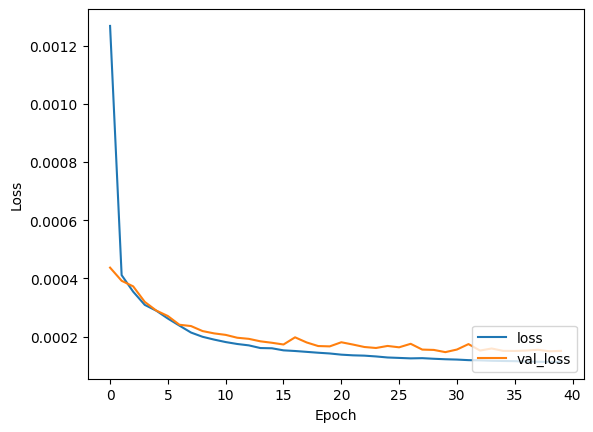

```python
import matplotlib.pyplot as plt
# Funció auxiliar per graficar accuracy i loss
plt.plot(history_gru.history['loss'], label='loss')
plt.plot(history_gru.history['val_loss'], label = 'val_loss')
plt.xlabel('Epoch')
plt.ylabel('Loss')
plt.legend(loc='lower right')
```

```python
from tensorflow.keras.callbacks import EarlyStopping
callback = EarlyStopping(monitor='val_loss', patience=10)
history_rnn = model_rnn.fit(X_train, y_train, epochs=100, batch_size=32, verbose=1,
                           validation_data=(X_test, y_test),callbacks=[callback])
```

```
3634/3634 ━━━━━━━━━━━━━━━━━━━━ 16s 4ms/step - loss: 0.0011 - val_loss: 3.5685e-04
3634/3634 ━━━━━━━━━━━━━━━━━━━━ 13s 4ms/step - loss: 3.5754e-04 - val_loss: 3.7157e-04
3634/3634 ━━━━━━━━━━━━━━━━━━━━ 13s 4ms/step - loss: 3.6512e-04 - val_loss: 3.6293e-04
3634/3634 ━━━━━━━━━━━━━━━━━━━━ 13s 4ms/step - loss: 3.5915e-04 - val_loss: 4.0726e-04
3634/3634 ━━━━━━━━━━━━━━━━━━━━ 13s 4ms/step - loss: 3.5010e-04 - val_loss: 3.4616e-04
3634/3634 ━━━━━━━━━━━━━━━━━━━━ 13s 4ms/step - loss: 3.2494e-04 - val_loss: 3.6142e-04
3634/3634 ━━━━━━━━━━━━━━━━━━━━ 13s 4ms/step - loss: 3.2327e-04 - val_loss: 3.5437e-04
3634/3634 ━━━━━━━━━━━━━━━━━━━━ 13s 4ms/step - loss: 3.1586e-04 - val_loss: 3.7219e-04
3634/3634 ━━━━━━━━━━━━━━━━━━━━ 13s 4ms/step - loss: 3.0480e-04 - val_loss: 3.6435e-04
3634/3634 ━━━━━━━━━━━━━━━━━━━━ 13s 3ms/step - loss: 2.9957e-04 - val_loss: 3.1011e-04
3634/3634 ━━━━━━━━━━━━━━━━━━━━ 13s 4ms/step - loss: 3.0495e-04 - val_loss: 3.0699e-04
3634/3634 ━━━━━━━━━━━━━━━━━━━━ 13s 4ms/step - loss: 2.8236e-04 - val_loss: 2.8986e-04
3634/3634 ━━━━━━━━━━━━━━━━━━━━ 13s 4ms/step - loss: 2.7660e-04 - val_loss: 3.2995e-04
3634/3634 ━━━━━━━━━━━━━━━━━━━━ 13s 3ms/step - loss: 2.5761e-04 - val_loss: 2.8354e-04
3634/3634 ━━━━━━━━━━━━━━━━━━━━ 13s 4ms/step - loss: 2.5885e-04 - val_loss: 2.8045e-04
3634/3634 ━━━━━━━━━━━━━━━━━━━━ 13s 3ms/step - loss: 2.4240e-04 - val_loss: 2.9198e-04
3634/3634 ━━━━━━━━━━━━━━━━━━━━ 13s 4ms/step - loss: 2.3456e-04 - val_loss: 2.8390e-04
3634/3634 ━━━━━━━━━━━━━━━━━━━━ 13s 4ms/step - loss: 2.3600e-04 - val_loss: 2.6673e-04
3634/3634 ━━━━━━━━━━━━━━━━━━━━ 13s 4ms/step - loss: 2.3025e-04 - val_loss: 2.6267e-04
3634/3634 ━━━━━━━━━━━━━━━━━━━━ 13s 4ms/step - loss: 2.2398e-04 - val_loss: 2.6636e-04
3634/3634 ━━━━━━━━━━━━━━━━━━━━ 13s 4ms/step - loss: 2.1954e-04 - val_loss: 2.5577e-04
3634/3634 ━━━━━━━━━━━━━━━━━━━━ 12s 3ms/step - loss: 2.2191e-04 - val_loss: 2.7151e-04
3634/3634 ━━━━━━━━━━━━━━━━━━━━ 13s 4ms/step - loss: 2.1603e-04 - val_loss: 2.6999e-04
3634/3634 ━━━━━━━━━━━━━━━━━━━━ 13s 4ms/step - loss: 2.1801e-04 - val_loss: 2.5266e-04
3634/3634 ━━━━━━━━━━━━━━━━━━━━ 13s 4ms/step - loss: 2.1020e-04 - val_loss: 2.3851e-04
3634/3634 ━━━━━━━━━━━━━━━━━━━━ 13s 4ms/step - loss: 2.0900e-04 - val_loss: 2.2860e-04
3634/3634 ━━━━━━━━━━━━━━━━━━━━ 13s 4ms/step - loss: 2.0773e-04 - val_loss: 2.5155e-04
3634/3634 ━━━━━━━━━━━━━━━━━━━━ 13s 4ms/step - loss: 2.1139e-04 - val_loss: 2.6850e-04
3634/3634 ━━━━━━━━━━━━━━━━━━━━ 13s 4ms/step - loss: 2.0926e-04 - val_loss: 2.3918e-04
3634/3634 ━━━━━━━━━━━━━━━━━━━━ 13s 4ms/step - loss: 2.0609e-04 - val_loss: 2.4342e-04
3634/3634 ━━━━━━━━━━━━━━━━━━━━ 13s 4ms/step - loss: 2.0543e-04 - val_loss: 2.2552e-04
3634/3634 ━━━━━━━━━━━━━━━━━━━━ 13s 4ms/step - loss: 2.0681e-04 - val_loss: 2.5403e-04
3634/3634 ━━━━━━━━━━━━━━━━━━━━ 13s 4ms/step - loss: 1.9801e-04 - val_loss: 2.6689e-04
3634/3634 ━━━━━━━━━━━━━━━━━━━━ 13s 4ms/step - loss: 2.0633e-04 - val_loss: 2.5218e-04
3634/3634 ━━━━━━━━━━━━━━━━━━━━ 13s 3ms/step - loss: 2.0083e-04 - val_loss: 2.2252e-04
3634/3634 ━━━━━━━━━━━━━━━━━━━━ 13s 4ms/step - loss: 1.9579e-04 - val_loss: 2.3789e-04
3634/3634 ━━━━━━━━━━━━━━━━━━━━ 13s 4ms/step - loss: 1.9849e-04 - val_loss: 2.3319e-04
3634/3634 ━━━━━━━━━━━━━━━━━━━━ 13s 4ms/step - loss: 1.9479e-04 - val_loss: 2.4765e-04
3634/3634 ━━━━━━━━━━━━━━━━━━━━ 13s 4ms/step - loss: 1.9531e-04 - val_loss: 2.5300e-04
3634/3634 ━━━━━━━━━━━━━━━━━━━━ 13s 4ms/step - loss: 1.9682e-04 - val_loss: 2.1888e-04
3634/3634 ━━━━━━━━━━━━━━━━━━━━ 12s 3ms/step - loss: 1.9280e-04 - val_loss: 2.0934e-04
3634/3634 ━━━━━━━━━━━━━━━━━━━━ 13s 4ms/step - loss: 1.9357e-04 - val_loss: 2.2385e-04
3634/3634 ━━━━━━━━━━━━━━━━━━━━ 13s 4ms/step - loss: 1.9439e-04 - val_loss: 2.1745e-04
3634/3634 ━━━━━━━━━━━━━━━━━━━━ 13s 4ms/step - loss: 1.9432e-04 - val_loss: 2.4004e-04
3634/3634 ━━━━━━━━━━━━━━━━━━━━ 13s 4ms/step - loss: 1.9138e-04 - val_loss: 2.1774e-04
3634/3634 ━━━━━━━━━━━━━━━━━━━━ 13s 4ms/step - loss: 1.9174e-04 - val_loss: 2.2599e-04
3634/3634 ━━━━━━━━━━━━━━━━━━━━ 13s 3ms/step - loss: 1.8652e-04 - val_loss: 2.1106e-04
3634/3634 ━━━━━━━━━━━━━━━━━━━━ 13s 4ms/step - loss: 1.9226e-04 - val_loss: 2.4369e-04
3634/3634 ━━━━━━━━━━━━━━━━━━━━ 13s 4ms/step - loss: 1.9027e-04 - val_loss: 2.1505e-04
3634/3634 ━━━━━━━━━━━━━━━━━━━━ 13s 4ms/step - loss: 1.8469e-04 - val_loss: 2.4201e-04
3634/3634 ━━━━━━━━━━━━━━━━━━━━ 13s 4ms/step - loss: 1.9099e-04 - val_loss: 2.2415e-04
```

[figure not shown]

```python
import matplotlib.pyplot as plt
#Funció auxiliar per graficar accuracy i loss
plt.plot(history_rnn.history['loss'], label='loss')
plt.plot(history_rnn.history['val_loss'], label = 'val_loss')
plt.xlabel('Epoch')
plt.ylabel('Accuracy')
plt.legend(loc='lower right')
```

```python
from tensorflow.keras.callbacks import EarlyStopping
callback = EarlyStopping(monitor='val_loss', patience=10)
history_lstm = model_lstm.fit(X_train, y_train, epochs=100, batch_size=32, verbose=1,
                            validation_data=(X_test, y_test),callbacks=[callback])
```

```
3634/3634 ━━━━━━━━━━━━━━━━━━━━ 15s 4ms/step - loss: 0.0055 - val_loss: 4.5450e-04
3634/3634 ━━━━━━━━━━━━━━━━━━━━ 14s 4ms/step - loss: 3.9968e-04 - val_loss: 3.6853e-04
3634/3634 ━━━━━━━━━━━━━━━━━━━━ 14s 4ms/step - loss: 3.4486e-04 - val_loss: 3.0739e-04
3634/3634 ━━━━━━━━━━━━━━━━━━━━ 14s 4ms/step - loss: 2.7793e-04 - val_loss: 3.3460e-04
3634/3634 ━━━━━━━━━━━━━━━━━━━━ 14s 4ms/step - loss: 2.6018e-04 - val_loss: 3.1500e-04
3634/3634 ━━━━━━━━━━━━━━━━━━━━ 14s 4ms/step - loss: 2.4930e-04 - val_loss: 2.4843e-04
3634/3634 ━━━━━━━━━━━━━━━━━━━━ 14s 4ms/step - loss: 2.2686e-04 - val_loss: 2.4542e-04
3634/3634 ━━━━━━━━━━━━━━━━━━━━ 14s 4ms/step - loss: 2.1797e-04 - val_loss: 2.4105e-04
3634/3634 ━━━━━━━━━━━━━━━━━━━━ 14s 4ms/step - loss: 2.1305e-04 - val_loss: 2.3419e-04
3634/3634 ━━━━━━━━━━━━━━━━━━━━ 14s 4ms/step - loss: 1.9520e-04 - val_loss: 2.3496e-04
3634/3634 ━━━━━━━━━━━━━━━━━━━━ 14s 4ms/step - loss: 1.8883e-04 - val_loss: 2.5451e-04
3634/3634 ━━━━━━━━━━━━━━━━━━━━ 14s 4ms/step - loss: 1.9372e-04 - val_loss: 2.3835e-04
3634/3634 ━━━━━━━━━━━━━━━━━━━━ 14s 4ms/step - loss: 1.8741e-04 - val_loss: 2.0881e-04
3634/3634 ━━━━━━━━━━━━━━━━━━━━ 14s 4ms/step - loss: 1.8071e-04 - val_loss: 2.1549e-04
3634/3634 ━━━━━━━━━━━━━━━━━━━━ 14s 4ms/step - loss: 1.7672e-04 - val_loss: 2.2832e-04
3634/3634 ━━━━━━━━━━━━━━━━━━━━ 14s 4ms/step - loss: 1.7341e-04 - val_loss: 2.0308e-04
3634/3634 ━━━━━━━━━━━━━━━━━━━━ 14s 4ms/step - loss: 1.6509e-04 - val_loss: 2.2130e-04
3634/3634 ━━━━━━━━━━━━━━━━━━━━ 14s 4ms/step - loss: 1.6750e-04 - val_loss: 2.0156e-04
3634/3634 ━━━━━━━━━━━━━━━━━━━━ 14s 4ms/step - loss: 1.6588e-04 - val_loss: 2.1943e-04
3634/3634 ━━━━━━━━━━━━━━━━━━━━ 14s 4ms/step - loss: 1.6246e-04 - val_loss: 2.1271e-04
3634/3634 ━━━━━━━━━━━━━━━━━━━━ 14s 4ms/step - loss: 1.5662e-04 - val_loss: 1.9853e-04
3634/3634 ━━━━━━━━━━━━━━━━━━━━ 14s 4ms/step - loss: 1.5926e-04 - val_loss: 1.8312e-04
3634/3634 ━━━━━━━━━━━━━━━━━━━━ 14s 4ms/step - loss: 1.5894e-04 - val_loss: 1.8623e-04
3634/3634 ━━━━━━━━━━━━━━━━━━━━ 14s 4ms/step - loss: 1.5357e-04 - val_loss: 2.1261e-04
3634/3634 ━━━━━━━━━━━━━━━━━━━━ 14s 4ms/step - loss: 1.4808e-04 - val_loss: 1.8130e-04
3634/3634 ━━━━━━━━━━━━━━━━━━━━ 14s 4ms/step - loss: 1.4709e-04 - val_loss: 1.9243e-04
3634/3634 ━━━━━━━━━━━━━━━━━━━━ 14s 4ms/step - loss: 1.4167e-04 - val_loss: 1.7963e-04
3634/3634 ━━━━━━━━━━━━━━━━━━━━ 14s 4ms/step - loss: 1.4035e-04 - val_loss: 1.7764e-04
3634/3634 ━━━━━━━━━━━━━━━━━━━━ 14s 4ms/step - loss: 1.3998e-04 - val_loss: 1.8043e-04
3634/3634 ━━━━━━━━━━━━━━━━━━━━ 14s 4ms/step - loss: 1.3720e-04 - val_loss: 1.8081e-04
3634/3634 ━━━━━━━━━━━━━━━━━━━━ 14s 4ms/step - loss: 1.3386e-04 - val_loss: 1.6514e-04
3634/3634 ━━━━━━━━━━━━━━━━━━━━ 14s 4ms/step - loss: 1.3482e-04 - val_loss: 1.7262e-04
3634/3634 ━━━━━━━━━━━━━━━━━━━━ 14s 4ms/step - loss: 1.3536e-04 - val_loss: 1.7464e-04
3634/3634 ━━━━━━━━━━━━━━━━━━━━ 14s 4ms/step - loss: 1.2505e-04 - val_loss: 1.6100e-04
3634/3634 ━━━━━━━━━━━━━━━━━━━━ 14s 4ms/step - loss: 1.2502e-04 - val_loss: 2.0123e-04
3634/3634 ━━━━━━━━━━━━━━━━━━━━ 14s 4ms/step - loss: 1.2778e-04 - val_loss: 1.6084e-04
3634/3634 ━━━━━━━━━━━━━━━━━━━━ 14s 4ms/step - loss: 1.2862e-04 - val_loss: 1.6223e-04
3634/3634 ━━━━━━━━━━━━━━━━━━━━ 14s 4ms/step - loss: 1.2604e-04 - val_loss: 1.6384e-04
3634/3634 ━━━━━━━━━━━━━━━━━━━━ 14s 4ms/step - loss: 1.2655e-04 - val_loss: 2.0524e-04
3634/3634 ━━━━━━━━━━━━━━━━━━━━ 14s 4ms/step - loss: 1.2696e-04 - val_loss: 1.5359e-04
```

[output cut: 17 more lines]

```
3634/3634 ━━━━━━━━━━━━━━━━━━━━ 14s 4ms/step - loss: 1.0642e-04 - val_loss: 1.5117e-04
3634/3634 ━━━━━━━━━━━━━━━━━━━━ 14s 4ms/step - loss: 1.0750e-04 - val_loss: 1.5487e-04
3634/3634 ━━━━━━━━━━━━━━━━━━━━ 14s 4ms/step - loss: 1.0648e-04 - val_loss: 1.5750e-04
3634/3634 ━━━━━━━━━━━━━━━━━━━━ 14s 4ms/step - loss: 1.0246e-04 - val_loss: 1.6606e-04
3634/3634 ━━━━━━━━━━━━━━━━━━━━ 14s 4ms/step - loss: 1.0885e-04 - val_loss: 1.4119e-04
3634/3634 ━━━━━━━━━━━━━━━━━━━━ 14s 4ms/step - loss: 1.0633e-04 - val_loss: 1.5334e-04
3634/3634 ━━━━━━━━━━━━━━━━━━━━ 14s 4ms/step - loss: 1.0825e-04 - val_loss: 1.4969e-04
3634/3634 ━━━━━━━━━━━━━━━━━━━━ 14s 4ms/step - loss: 1.0553e-04 - val_loss: 1.4968e-04
3634/3634 ━━━━━━━━━━━━━━━━━━━━ 14s 4ms/step - loss: 1.0041e-04 - val_loss: 1.4300e-04
3634/3634 ━━━━━━━━━━━━━━━━━━━━ 14s 4ms/step - loss: 1.0369e-04 - val_loss: 1.4359e-04
3634/3634 ━━━━━━━━━━━━━━━━━━━━ 14s 4ms/step - loss: 1.0659e-04 - val_loss: 1.4738e-04
3634/3634 ━━━━━━━━━━━━━━━━━━━━ 14s 4ms/step - loss: 1.0256e-04 - val_loss: 1.4292e-04
3634/3634 ━━━━━━━━━━━━━━━━━━━━ 14s 4ms/step - loss: 1.0344e-04 - val_loss: 1.4427e-04
3634/3634 ━━━━━━━━━━━━━━━━━━━━ 14s 4ms/step - loss: 1.0599e-04 - val_loss: 1.4451e-04
3634/3634 ━━━━━━━━━━━━━━━━━━━━ 14s 4ms/step - loss: 1.0576e-04 - val_loss: 1.5398e-04
```

[figure not shown]

```python
import matplotlib.pyplot as plt
# Funció auxiliar per graficar accuracy i loss
plt.plot(history_lstm.history['loss'], label='loss')
plt.plot(history_lstm.history['val_loss'], label = 'val_loss')
plt.xlabel('Epoch')
plt.ylabel('Accuracy')
plt.legend(loc='lower right')
```